# Naive Bayes on Pima Indians Dataset

We will use Naive Bayes to model the "Pima Indians Diabetes" data set. This model will predict which people are likely to develop diabetes.

This dataset is originally from the National Institute of Diabetes and Digestive and Kidney Diseases. The objective of the dataset is to diagnostically predict whether or not a patient has diabetes, based on certain diagnostic measurements included in the dataset. Several constraints were placed on the selection of these instances from a larger database. In particular, all patients here are females at least 21 years old of Pima Indian heritage.

## Features in the dataet:

1. Pregnancies: Number of times pregnant
2. Glucose: Plasma glucose concentration a 2 hours in an oral glucose tolerance test
3. BloodPressure: Diastolic blood pressure (mm Hg)
4. SkinThickness: Triceps skin fold thickness (mm)
5. Insulin: 2-Hour serum insulin (mu U/ml)
6. BMI: Body mass index (weight in kg/(height in m)^2)
7. DiabetesPedigreeFunction: Diabetes pedigree function
8. Age: Age (years)
9. Outcome: Class variable (0 or 1)

## Import Libraries

```python
import numpy as np # linear algebra
import pandas as pd # data processing, CSV file I/O (e.g. pd.read_csv)
import matplotlib.pyplot as plt       # matplotlib.pyplot plots data
%matplotlib inline

import seaborn as sns   # visualization
```

## Load and review data

```python
pdata = pd.read_csv("pima-indians-diabetes-2.csv")
```

```python
pdata.shape # Check number of columns and rows in data frame
```

```
(768, 9)
```

```python
pdata.head() # To check first 5 rows of data set
```

|  | Preg | Plas | Pres | skin | test | mass | pedi | age | class |
| --- | --- | --- | --- | --- | --- | --- | --- | --- | --- |
| 0 | 6 | 148 | 72 | 35 | 0 | 33.6 | 0.627 | 50 | 1 |
| 1 | 1 | 85 | 66 | 29 | 0 | 26.6 | 0.351 | 31 | 0 |
| 2 | 8 | 183 | 64 | 0 | 0 | 23.3 | 0.672 | 32 | 1 |
| 3 | 1 | 89 | 66 | 23 | 94 | 28.1 | 0.167 | 21 | 0 |
| 4 | 0 | 137 | 40 | 35 | 168 | 43.1 | 2.288 | 33 | 1 |

```python
pdata.isnull().values.any() # If there are any null values in data set
```

```
False
```

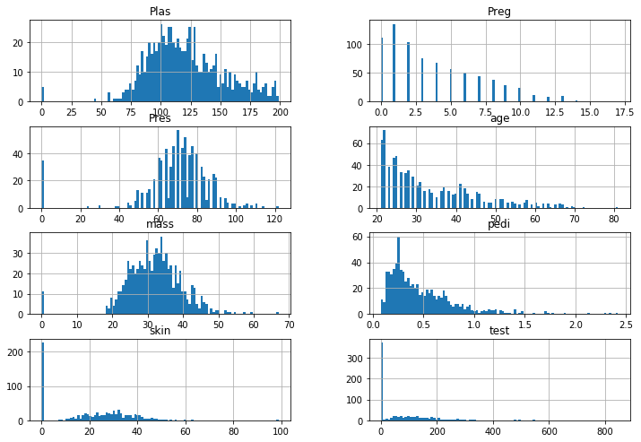

```python
columns = list(pdata)[0:-1] # Excluding Outcome column which has only
pdata[columns].hist(stacked=False, bins=100, figsize=(12,30),layout=(14,2));
# Histogram of first 8 columns
```

## Identify Correlation in data

```python
pdata.corr() # It will show correlation matrix
```

|  | Preg | Plas | Pres | skin | test | mass | pedi | age | class |
| --- | --- | --- | --- | --- | --- | --- | --- | --- | --- |
| Preg | 1.000000 | 0.129459 | 0.141282 | -0.081672 | -0.073535 | 0.017683 | -0.033523 | 0.544341 | 0.221898 |
| Plas | 0.129459 | 1.000000 | 0.152590 | 0.057328 | 0.331357 | 0.221071 | 0.137337 | 0.263514 | 0.466581 |
| Pres | 0.141282 | 0.152590 | 1.000000 | 0.207371 | 0.088933 | 0.281805 | 0.041265 | 0.239528 | 0.065068 |
| skin | -0.081672 | 0.057328 | 0.207371 | 1.000000 | 0.436783 | 0.392573 | 0.183928 | -0.113970 | 0.074752 |
| test | -0.073535 | 0.331357 | 0.088933 | 0.436783 | 1.000000 | 0.197859 | 0.185071 | -0.042163 | 0.130548 |
| mass | 0.017683 | 0.221071 | 0.281805 | 0.392573 | 0.197859 | 1.000000 | 0.140647 | 0.036242 | 0.292695 |
| pedi | -0.033523 | 0.137337 | 0.041265 | 0.183928 | 0.185071 | 0.140647 | 1.000000 | 0.033561 | 0.173844 |
| age | 0.544341 | 0.263514 | 0.239528 | -0.113970 | -0.042163 | 0.036242 | 0.033561 | 1.000000 | 0.238356 |
| class | 0.221898 | 0.466581 | 0.065068 | 0.074752 | 0.130548 | 0.292695 | 0.173844 | 0.238356 | 1.000000 |

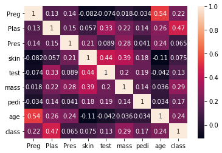

```python
sns.heatmap(pdata.corr(), annot=True);
```

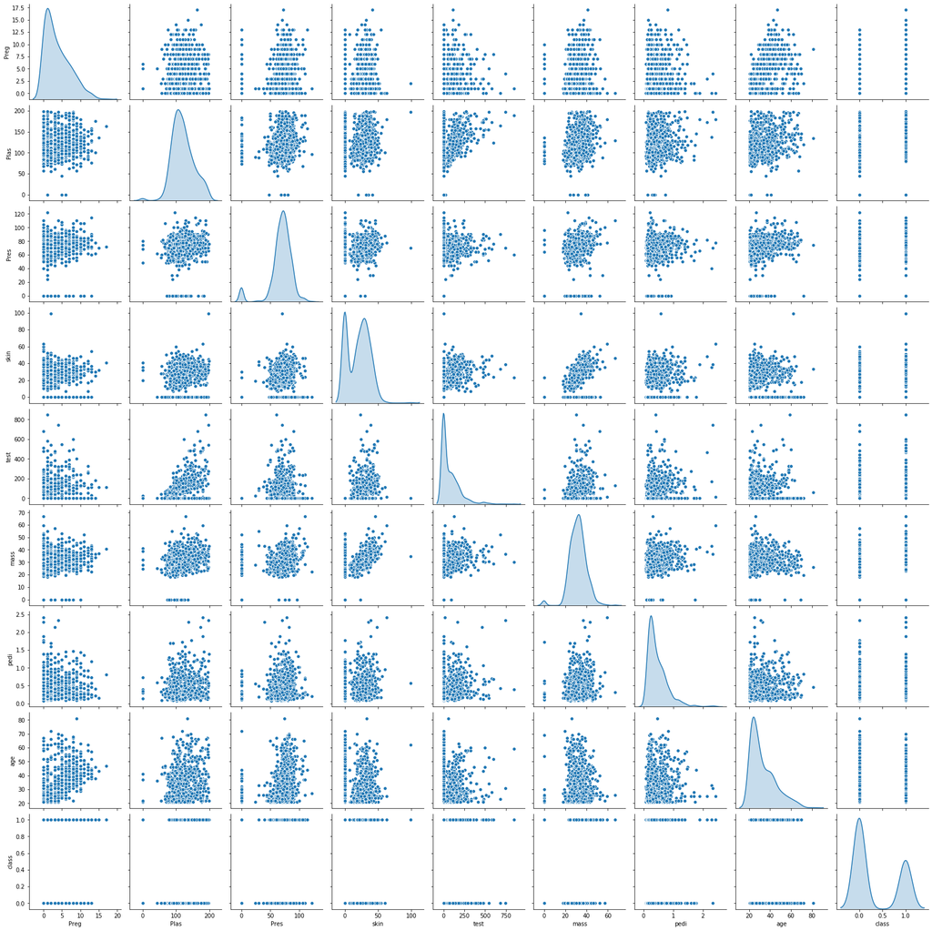

```python
sns.pairplot(pdata,diag_kind='kde')   # bivariate
```

## Calculate diabetes ratio of True/False from outcome variable

```python
n_true = len(pdata.loc[pdata['class'] == True])
n_false = len(pdata.loc[pdata['class'] == False])
print("positive class",n_true,"neg class",n_false)
```

```
positive class 268 neg class 500
```

```python
print("Number of true cases: {0} ({1:2.2f}%)".format(n_true, (n_true / (n_true + n_false)) * 100 ))
print("Number of false cases: {0} ({1:2.2f}%)".format(n_false, (n_false / (n_true + n_false)) * 100))
```

```
Number of true cases: 268 (34.90%)
Number of false cases: 500 (65.10%)
```

So we have 34.90% people in current data set who have diabetes and rest of 65.10% doesn't have diabetes.

Its a good distribution True/False cases of diabetes in data.

## Spliting the data

I will use 70% of data for training and 30% for testing.

```python
from sklearn.model_selection import train_test_split

X = pdata.drop('class',axis=1)     # Predictor feature columns (8 X m)

Y = pdata['class']   # Predicted class (1=True, 0=False) (1 X m)

x_train, x_test, y_train, y_test = train_test_split(X, Y, test_size=0.3, random_state=1)
# 1 is just any random seed number

x_train.head()
```

|  | Preg | Plas | Pres | skin | test | mass | pedi | age |
| --- | --- | --- | --- | --- | --- | --- | --- | --- |
| 88 | 15 | 136 | 70 | 32 | 110 | 37.1 | 0.153 | 43 |
| 467 | 0 | 97 | 64 | 36 | 100 | 36.8 | 0.600 | 25 |
| 550 | 1 | 116 | 70 | 28 | 0 | 27.4 | 0.204 | 21 |
| 147 | 2 | 106 | 64 | 35 | 119 | 30.5 | 1.400 | 34 |
| 481 | 0 | 123 | 88 | 37 | 0 | 35.2 | 0.197 | 29 |

Lets check split of data

```python
print("{0:0.2f}% data is in training set".format((len(x_train)/len(pdata.index)) * 100))
print("{0:0.2f}% data is in test set".format((len(x_test)/len(pdata.index)) * 100))
```

```
69.92% data is in training set
30.08% data is in test set
```

Now lets check diabetes True/False ratio in split data

```python
print("Original Diabetes True Values    : {0} ({1:0.2f}%)".format(len(pdata.loc[pdata['class'] == 1]), (len(pdata.loc[pdata['class'] == 1])/len(pdata.index)) * 100))
print("Original Diabetes False Values   : {0} ({1:0.2f}%)".format(len(pdata.loc[pdata['class'] == 0]), (len(pdata.loc[pdata['class'] == 0])/len(pdata.index)) * 100))
print("")
print("Training Diabetes True Values    : {0} ({1:0.2f}%)".format(len(y_train[y_train[:] == 1]), (len(y_train[y_train[:] == 1])/len(y_train)) * 100))
print("Training Diabetes False Values   : {0} ({1:0.2f}%)".format(len(y_train[y_train[:] == 0]), (len(y_train[y_train[:] == 0])/len(y_train)) * 100))
print("")
print("Test Diabetes True Values        : {0} ({1:0.2f}%)".format(len(y_test[y_test[:] == 1]), (len(y_test[y_test[:] == 1])/len(y_test)) * 100))
print("Test Diabetes False Values       : {0} ({1:0.2f}%)".format(len(y_test[y_test[:] == 0]), (len(y_test[y_test[:] == 0])/len(y_test)) * 100))
print("")
```

```
Original Diabetes True Values    : 268 (34.90%)
Original Diabetes False Values   : 500 (65.10%)

Training Diabetes True Values    : 183 (34.08%)
Training Diabetes False Values   : 354 (65.92%)

Test Diabetes True Values        : 85 (36.80%)
Test Diabetes False Values       : 146 (63.20%)
```

# Data Preparation

### Check hidden missing values

As we checked missing values earlier but haven't got any. But there can be lots of entries with 0 values. We must need to take care of those as well.

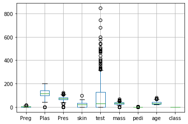

```python
pdata.boxplot()
```

```python
x_train.head()
```

|  | Preg | Plas | Pres | skin | test | mass | pedi | age |
| --- | --- | --- | --- | --- | --- | --- | --- | --- |
| 88 | 15 | 136 | 70 | 32 | 110 | 37.1 | 0.153 | 43 |
| 467 | 0 | 97 | 64 | 36 | 100 | 36.8 | 0.600 | 25 |
| 550 | 1 | 116 | 70 | 28 | 0 | 27.4 | 0.204 | 21 |
| 147 | 2 | 106 | 64 | 35 | 119 | 30.5 | 1.400 | 34 |
| 481 | 0 | 123 | 88 | 37 | 0 | 35.2 | 0.197 | 29 |

We can see lots of 0 entries above.

```python
#from sklearn.preprocessing import Imputer
#my_imputer = Imputer()
#data_with_imputed_values = my_imputer.fit_transform(original_data)

from sklearn.impute import SimpleImputer
rep_0 = SimpleImputer(missing_values=0, strategy="median")
cols=x_train.columns
x_train = pd.DataFrame(rep_0.fit_transform(x_train))
x_test = pd.DataFrame(rep_0.fit_transform(x_test))

x_train.columns = cols
x_test.columns = cols

x_train.head()
```

|  | Preg | Plas | Pres | skin | test | mass | pedi | age |
| --- | --- | --- | --- | --- | --- | --- | --- | --- |
| 0 | 15.0 | 136.0 | 70.0 | 32.0 | 110.0 | 37.1 | 0.153 | 43.0 |
| 1 | 3.0 | 97.0 | 64.0 | 36.0 | 100.0 | 36.8 | 0.600 | 25.0 |
| 2 | 1.0 | 116.0 | 70.0 | 28.0 | 130.0 | 27.4 | 0.204 | 21.0 |
| 3 | 2.0 | 106.0 | 64.0 | 35.0 | 119.0 | 30.5 | 1.400 | 34.0 |
| 4 | 3.0 | 123.0 | 88.0 | 37.0 | 130.0 | 35.2 | 0.197 | 29.0 |

# Train Naive Bayes algorithm

```python
from sklearn.naive_bayes import GaussianNB # using Gaussian algorithm from Naive Bayes

# creatw the model
diab_model = GaussianNB()

diab_model.fit(x_train, y_train.ravel())
```

```
GaussianNB()
```

### Performance of our model with training data

```python
diab_train_predict = diab_model.predict(x_train)

from sklearn import metrics

print("Model Accuracy on train data",metrics.accuracy_score(y_train, diab_train_predict))
```

```
Model Accuracy on train data 0.7411545623836127
```

### Performance of our model with testing data

```python
diab_test_predict = diab_model.predict(x_test)

from sklearn import metrics

print("Model Accuracy: {0:.4f}".format(metrics.accuracy_score(y_test, diab_test_predict)))
print()
```

[output not shown]

### Lets check the confusion matrix and classification report

```
Confusion Matrix
```

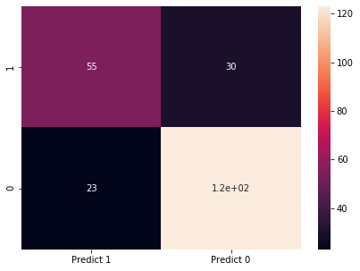

```python
print("Confusion Matrix")
cm=metrics.confusion_matrix(y_test, diab_test_predict, labels=[1, 0])

df_cm = pd.DataFrame(cm, index = [i for i in ["1","0"]],
                  columns = [i for i in ["Predict 1","Predict 0"]])
plt.figure(figsize = (7,5))
sns.heatmap(df_cm, annot=True)
```

```python
print("Classification Report")
print(metrics.classification_report(y_test, diab_test_predict, labels=[1, 0]))
```

```
Classification Report
              precision    recall  f1-score   support

           1       0.70      0.65      0.67        85
           0       0.80      0.84      0.82       146

    accuracy                           0.77       231
   macro avg       0.75      0.74      0.74       231
weighted avg       0.76      0.77      0.76       231
```